# Análise de crimes em Chicago

Ana Morato, Cristiane Zhu, Joaquim Almeida, Mário Sena

true

Abstract

O objetivo do presente estudo é analisar e comparar dados de incidentes criminais da cidade de Chicago. Chicago é uma cidade localizada nos Estados Unidos que possui uma das maiores taxas de criminalidade no país. Separada em 22 distritos policiais, foi verificado que o distrito 8, chamado Chicago Lawn, é o que mais ocorreu incidentes criminais entre os anos de 2001 e 2017. Além disso, foi feita uma pesquisa dos principais feriados da cidade e foram encontradas 10 datas significantes para uma análise, tendo como resultado o Ano Novo com uma média de crimes muito mais alta que as outras e além de datas comemorativas, foi observado a ocorência de crimes por dias da semana e meses.Ademais, para analisar uma possível dependência entre o tipo de crime e o número de prisões e não prisões, foi feito o teste qui-quadrado, comprovando a associação entre as duas variáveis. Por fim, foi feita a análise descritiva da média de ocorrências criminais por localidade

## 1 Introdução

A cidade de Chicago localizada nos Estados Unidos é bastante reconhecida pela sua arquitetura urbana, parques, influência econômica, entre outros. Além disso, é a terceira maior cidade do seu país com uma população de aproximadamente três milhões de pessoas (Wikipedia 2024).

Assim como toda metrópole de grande porte, Chicago também enfrenta desafios urbanos como a segurança pública. O município possui uma das maiores taxas de criminalidade nos Estados Unidos em comparação com todas as comunidades de todos tamanhos, sendo essa taxa de 37 por mil habitantes (Scout 2024) .

Tendo isso em vista, o objetivo deste estudo é analisar a incidência de crimes em determinados distritos no decorrer dos anos de 2001 a 2017, obtendo uma visão geral da distribuição dos crimes, além de verificar o perigo em datas comemorativas como feriados, analisar e verificar se há associação entre tipos de crimes e se houve prisão ou não ,observar o comportamento das diversas características de ocorrência de crimes em certos dias da semana e meses e obter a média de ocorrências criminais por localidade.

## 2 Materiais e Métodos

### 2.1 Materiais

Todas as análises foram realizadas no R, bem como a elaboração das tabelas e dos gráficos.

### 2.2 Coleta de dados

A fim de avaliar os incidentes de crimes relatados em Chicago , iniciou-se lendo os bancos de dados `Chicago_Crimes_2001_to_2004.csv`, `Chicago_Crimes_2005_to_2007.csv`, `Chicago_Crimes_2008_to_2011.csv`, `Chicago_Crimes_2012_to_2017.csv`, que contém informações sobre o crime ocorrido, bem como a data, a descrição, localização e detalhes específicos dos incidentes. Os dados foram extraídos do sistema CLEAR (Citizen Law Enforcement Analysis and Reporting) do Departamento de Polícia de Chicago e estão disponíveis na plataforma Kaggle (https://www.kaggle.com/datasets/currie32/crimes-in-chicago).

```r
#| label: carregando os pacotes
require(data.table)
require(magrittr)
require(tidyverse)
require(ggplot2)
require(sf)
require(readr)
library(showtext)
library(scales)
```

```r
#| label: leitura dos dados sobre crimes em Chicago
data_2001_2004 <- fread("Chicago_Crimes_2001_to_2004.csv")
data_2005_2007 <- fread("Chicago_Crimes_2005_to_2007.csv")
data_2008_2011 <- fread("Chicago_Crimes_2008_to_2011.csv")
data_2012_2017 <- fread("Chicago_Crimes_2012_to_2017.csv")
```

Foi utilizado também um banco de dados adicional para plotar um gráfico em formato de mapa para ilustrar os crimes divididos por cada distrito de Chicago. Os dados foram obtidos do próprio site da cidade (https://data.cityofchicago.org/Public-Safety/Boundaries-Police-Districts/4dt9-88ua/about_data) e contém informações como o rótulo do distrito (`DIST_LABEL`), o número do distrito (`DIST_NUM`) e a geometria (`geometry`).

```r
#unzip("/shapefile_dir/", exdir = "/shapefile_dir/")

distritos <- st_read("shapefile_dir/PoliceDistrict.shp")
```

### 2.3 Pré-processamento dos dados

Para facilitar a análise dos dados, foi realizado um pré-processamento deles, incluindo a sua limpeza, redução e a junção dos bancos.O pré-processamento dos bancos de dados foi realizado de forma individual, pois essa abordagem se mostrou mais vantajosa em termos de tamanho e peso dos dados.

Primeiramente, após uma avaliação geral dos 4 bancos de dados sobre a incidência de crimes em Chicago, verificou-se a existência de diversas variáveis irrelevantes para a análise proposta, como a variável (`V1`), o Número RD(número da divisão de registros) do Departamento de Polícia de Chicago (`Case Number`) e o código de denúncia de crimes da Unifrom Illinois (`IUCR`). Portanto, essas foram removidas dos bancos de dados.

Além disso, foi necessário limpar os dados, isto é, lidar com as observações duplicadas, faltantes e não especificadas. Neste caso, foram verificadas observações não disponíveis (NA) que foram omitidas.

```r
na_data_2001_2004 <- data_2001_2004 %>%
    select(-V1, -`Case Number`, -IUCR) %>%
    drop_na()

na_data_2005_2007 <- data_2005_2007 %>%
    select(-V1, -`Case Number`, -IUCR) %>%
    drop_na()


na_data_2008_2011 <- data_2008_2011 %>%
    select(-V1, -`Case Number`, -IUCR) %>%
    drop_na()

na_data_2012_2017 <- data_2012_2017 %>%
    select(-V1, -`Case Number`, -IUCR) %>%
    drop_na()
```

Após a remoção de um grande número de observações, o que resultou em bancos de dados mais leves, os quatro dataframes foram unidos para, em seguida, prosseguir com a manipulação necessária das variáveis.

```r
data_frame <- rbind(na_data_2001_2004, na_data_2005_2007, na_data_2008_2011, na_data_2012_2017)
glimpse(data_frame)
```

```
## Rows: 3,970,186
## Columns: 20
## $ ID                     <int> 4676906, 4677901, 4791194, 4679521, 4680124, 46…
## $ Date                   <chr> "03/01/2003 12:00:00 AM", "05/01/2003 01:00:00 …
## $ Block                  <chr> "004XX W 42ND PL", "111XX S NORMAL AVE", "114XX…
## $ `Primary Type`         <chr> "OTHER OFFENSE", "THEFT", "CRIM SEXUAL ASSAULT"…
## $ Description            <chr> "HARASSMENT BY TELEPHONE", "FINANCIAL ID THEFT:…
## $ `Location Description` <chr> "RESIDENCE", "RESIDENCE", "RESIDENCE", "RESIDEN…
## $ Arrest                 <lgl> FALSE, FALSE, TRUE, FALSE, FALSE, FALSE, FALSE,…
## $ Domestic               <lgl> TRUE, FALSE, TRUE, FALSE, FALSE, FALSE, FALSE, …
## $ Beat                   <int> 935, 2233, 531, 2222, 1134, 2223, 813, 922, 823…
## $ District               <dbl> 9, 22, 5, 22, 11, 22, 8, 9, 8, 14, 8, 9, 7, 7, …
## $ Ward                   <dbl> 11, 34, 9, 21, 24, 21, 13, 11, 15, 26, 13, 12, …
## $ `Community Area`       <dbl> 61, 49, 50, 73, 29, 73, 65, 59, 66, 23, 62, 59,…
## $ `FBI Code`             <chr> "26", "06", "02", "26", "06", "06", "06", "06",…
## $ `X Coordinate`         <dbl> 1173974, 1174948, 1182247, 1169911, 1154521, 11…
## $ `Y Coordinate`         <dbl> 1876757, 1831051, 1829375, 1844832, 1895755, 18…
## $ Year                   <int> 2003, 2003, 2001, 2003, 2003, 2003, 2003, 2003,…
## $ `Updated On`           <chr> "04/15/2016 08:55:02 AM", "04/15/2016 08:55:02 …
## $ Latitude               <dbl> 41.81723, 41.69178, 41.68702, 41.72971, 41.8697…
## $ Longitude              <dbl> -87.63733, -87.63512, -87.60845, -87.65316, -87…
## $ Location               <chr> "(41.817229156, -87.637328162)", "(41.691784636…
```

Dando continuidade às mudanças, foi feito a renomeação das variáveis, substituindo letras maiúsculas e espaços por underline já que é uma prática recomendada que garante a compatibilidade, clareza e organização dos nomes de variáveis, além de facilitar a manipulação nos processos de programação e análise de dados.

```r
rename_dataframe <- data_frame %>%
  rename(
    id = ID,
    date = Date,
    block = Block,
    primary_type = `Primary Type`,
    description = Description,
    locations_description = `Location Description`,
    arrest = Arrest,
    domestic = Domestic,
    beat = Beat,
    district = District,
    ward = Ward,
    community_area = `Community Area`,
    fbi_code = `FBI Code`,
    x_coordinate = `X Coordinate`,
    y_coordinate = `Y Coordinate`,
    year = Year,
    updated_on = `Updated On`,
    latitude = Latitude,
    longitude = Longitude,
    location = Location
  )
```

Por fim, foi modificada a classe da variável (`date`) e adicionada duas colunas novas (`year`) e (`month`) para facilitar análises futuras. Após a execução de todos os passos anteriores, foi possível obter um banco de dados limpo, organizado e contendo apenas as informações necessárias para dar início a um dos estudos.

```r
rename_dataframe$date <- as.POSIXct(rename_dataframe$date, format = "%m/%d/%Y %I:%M:%S %p")
rename_dataframe$year <- format(rename_dataframe$date, "%Y")
rename_dataframe$month <- format(rename_dataframe$date, "%Y-%m")

# write.csv(rename_dataframe, file = crimes_chicago.csv)
crimes_chicago <- fread("crimes_chicago.csv")
```

Posteriormente, identificou-se a necessidade de criar um banco de dados adicional, cuja finalidade seria analisar os crimes ocorridos em períodos de feriados. Para tanto, definiu-se os feriados relevantes e suas respectivas datas no período de 2001 a 2017, uma tarefa que se mostrou viável devido à disponibilidade dessas informações. Foi elaborada, então, uma tabela complementar denominada “feriados”, contendo as datas dos feriados e suas respectivas denominações. Os feriados selecionados seguiram o critério de serem dias em que há suspensão de atividades laborais e escolares.

```r
feriados <- data.frame(
  Date = c("01/01/2004", "01/19/2004", "02/16/2004", "05/31/2004", "07/04/2004", "09/06/2004", "10/11/2004",
           "11/11/2004", "11/25/2004", "12/25/2004",
           "01/01/2005", "01/17/2005", "02/21/2005", "05/30/2005", "07/04/2005", "09/05/2005", "10/10/2005",
           "11/11/2005", "11/24/2005", "12/25/2005",
           "01/01/2006", "01/16/2006", "02/20/2006", "05/29/2006", "07/04/2006", "09/04/2006", "10/09/2006",
           "11/11/2006", "11/23/2006", "12/25/2006",
           "01/01/2007", "01/15/2007", "02/19/2007", "05/28/2007", "07/04/2007", "09/03/2007", "10/08/2007",
           "11/11/2007", "11/22/2007", "12/25/2007",
           "01/01/2008", "01/21/2008", "02/18/2008", "05/26/2008", "07/04/2008", "09/01/2008", "10/13/2008",
           "11/11/2008", "11/27/2008", "12/25/2008",
           "01/01/2009", "01/19/2009", "02/16/2009", "05/25/2009", "07/04/2009", "09/07/2009", "10/12/2009",
           "11/11/2009", "11/26/2009", "12/25/2009",
           "01/01/2010", "01/18/2010", "02/15/2010", "05/31/2010", "07/04/2010", "09/06/2010", "10/11/2010",
           "11/11/2010", "11/25/2010", "12/25/2010",
           "01/01/2011", "01/17/2011", "02/21/2011", "05/30/2011", "07/04/2011", "09/05/2011", "10/10/2011",
           "11/11/2011", "11/24/2011", "12/25/2011",
           "01/01/2012", "01/16/2012", "02/20/2012", "05/28/2012", "07/04/2012", "09/03/2012", "10/08/2012",
           "11/11/2012", "11/22/2012", "12/25/2012",
           "01/01/2013", "01/21/2013", "02/18/2013", "05/27/2013", "07/04/2013", "09/02/2013", "10/14/2013",
           "11/11/2013", "11/28/2013", "12/25/2013",
           "01/01/2014", "01/20/2014", "02/17/2014", "05/26/2014", "07/04/2014", "09/01/2014", "10/13/2014",
           "11/11/2014", "11/27/2014", "12/25/2014",
           "01/01/2015", "01/19/2015", "02/16/2015", "05/25/2015", "07/04/2015", "09/07/2015", "10/12/2015",
           "11/11/2015", "11/26/2015", "12/25/2015",
           "01/01/2016", "01/18/2016", "02/15/2016", "05/30/2016", "07/04/2016", "09/05/2016", "10/10/2016",
           "11/11/2016", "11/24/2016", "12/25/2016",
           "01/01/2017", "01/16/2017", "02/20/2017", "05/29/2017", "07/04/2017", "09/04/2017", "10/09/2017",
           "11/11/2017", "11/23/2017", "12/25/2017"),
  Feriado = rep(c("Ano Novo", "Martin Luther King Jr. Day", "Presidents' Day", "Memorial Day", "Independence Day", "Labor Day",
                  "Columbus Day/Indigenous Peoples' Day", "Veterans Day", "Thanksgiving Day", "Christmas Day"), times = 14)
)

feriados$Date <- as.Date(feriados$Date, format = "%m/%d/%Y")
```

Além dessa tabela, foi criada uma cópia do banco de dados de crimes_chicago para que ele pudesse ser ajustado e integrado à tabela de feriados. Essa abordagem visa facilitar a análise comparativa da criminalidade nos períodos festivos da cidade.

```r
data0 <- read_csv("Chicago_Crimes_2001_to_2004.csv") %>%
  full_join(read_csv("Chicago_Crimes_2005_to_2007.csv")) %>%
  full_join(read_csv("Chicago_Crimes_2008_to_2011.csv")) %>%
  full_join(read_csv("Chicago_Crimes_2012_to_2017.csv"))
```

[output not shown]

```r
data0 <- data0 %>%
  distinct(ID, .keep_all = TRUE)

data0$Date <- as.Date(data0$Date, format = "%m/%d/%Y")
```

Em seguida, unificaram-se as tabelas de crimes_chicago e feriados, de forma que as ocorrências pudessem ser classificadas conforme as datas comemorativas. Os crimes ocorridos fora dos feriados foram marcados explicitamente para facilitar a visualização e análise.

```r
data0 <- merge(data0, feriados[, c("Date", "Feriado")], by.x = "Date", by.y = "Date", all.x = TRUE)
data0$Feriado[is.na(data0$Feriado)] <- "Não é feriado"

data_feriados <- data0 %>% filter(Feriado != "Não é feriado")
```

Por fim, adicionaram-se ao banco de dados `data_feriados` três colunas adicionais que classificam os crimes como pertencentes às categorias de Violência, Perturbação Pública ou Crimes contra a Propriedade, conforme o tipo principal de crime registrado.

```r
data_feriados <- data_feriados %>%
  mutate(
    Violento = case_when(
      `Primary Type` %in% c(
        "ASSAULT",
        "BATTERY",
        "HOMICIDE",
        "ROBBERY",
        "KIDNAPPING",
        "STALKING",
        "CRIMINAL SEXUAL ASSAULT",
        "ARSON"
      ) ~ "Violento",
      TRUE ~ "Nao Violento"
    ),
    Perturbacao_Publica = case_when(
      `Primary Type` %in% c(
        "PUBLIC PEACE VIOLATION",
        "INTERFERENCE WITH PUBLIC OFFICER",
        "PUBLIC INDECENCY",
        "DISORDERLY CONDUCT"
      ) ~ "Perturbação Pública",
      TRUE ~ "Nao Perturbacao Publica"
    ),

    Propriedade = case_when(
      `Primary Type` %in% c(
        "BURGLARY",
        "MOTOR VEHICLE THEFT",
        "THEFT",
        "CRIMINAL DAMAGE",
        "CRIMINAL TRESPASS",
        "ARSON"
      ) ~ "Crime a Propriedade",
      TRUE ~ "Nao Propriedade"
    )
  )
```

Dessa forma, a tabela final está pronta para análises detalhadas que avaliem a relação entre os feriados e as taxas de criminalidade, bem como os tipos de crime mais recorrentes nesses períodos. Essa segmentação permitirá insights mais precisos sobre os padrões criminais durante feriados em Chicago.

Para a análise da evolução dos crimes ao longo do tempo, considerou-se essencial criar uma cópia do banco de dados contendo apenas as variáveis relevantes para a análise gráfica. A tabela foi nomeada `tb1` e as variáveis selecionadas foram: `id`, `date`, `arrest`, `year`, `primary_type` e `domestic`.

```r
# Selecionando variáveis de interesse
tb1 <- crimes_chicago %>%
  select(id,date, arrest, year,primary_type, domestic) %>%
  separate(date, into = c("Data", "Hora"), sep = " ")
```

Além disso, a partir da variável `date`, foram derivadas duas novas colunas: `dia_semana` e `nome_mes`. Essas colunas adicionais são fundamentais para facilitar comparações na frequência de crimes ao longo dos meses e entre os diferentes dias da semana.

```r
tb1$Data <- as.Date(tb1$Data, format = "%Y-%m-%d")
tb1$dia_semana <- weekdays(tb1$Data)
tb1$ano <- year(tb1$Data)
tb1 <- tb1 %>%
  mutate(nome_mes = format(Data, "%B")) %>%  # Evitar avisos sobre agrupamento
  mutate(
    # Order days of the week
      dia_semana = factor(
        dia_semana,
        levels = c("domingo","segunda-feira", "terça-feira", "quarta-feira", "quinta-feira", "sexta-feira", "sábado")),
    # Order months
    nome_mes = factor(

      nome_mes,
      levels = c("janeiro", "fevereiro", "março", "abril", "maio", "junho",
                 "julho", "agosto", "setembro", "outubro", "novembro", "dezembro")
    )
  )
```

### 2.4 Análise descritiva

A cidade de Chicago é separada em 22 distritos policiais, isto é, ela é dividida em áreas geográficas e patrulhada por forças policiais diferentes. Tendo isso em vista, com o objetivo de analisar o número de incidentes de criminalidade em cada distrito, foi feita uma análise descritiva da distribuição de frequência para verificar se há padrões entre eles.

Para apresentar os dados de forma clara, foi elaborado um gráfico de barras, representado no gráfico `Números de crimes por distritos`, destacando a distribuição do número de crimes por distrito. Além disso, para fornecer uma visualização mais intuitiva, foi criada uma visualização geoespacial, exibida logo a seguir, que ilustra a concentração de crimes nas diferentes áreas analisadas.

#### Número de crimes por distritos

```r
crimes_chicago2 <- crimes_chicago %>%
  select(
    -V1,
    -block,
    -id,
    -arrest,
    -domestic,
    -locations_description,
    -fbi_code,
    -updated_on,
    -beat,
    -longitude,
    -latitude,
    -x_coordinate,
    -y_coordinate,
    -location
  ) %>%
  mutate(distrito_char = as.character(district)) %>%  #deixar na mesma classe do banco do mapa
  group_by(distrito_char) %>%
  summarise(num_crimes = n()) %>%
  filter(distrito_char != "13" & distrito_char != "31", distrito_char != "21") %>%  # valores desprezíveis
  arrange(desc(num_crimes)) %>%
  mutate(distrito_char = fct_reorder(distrito_char, num_crimes))
```

#### Tabela do número de crimes

```r
tabe<- data.table(crimes_chicago2)
setnames(tabe, old = c("distrito_char", "num_crimes"), new = c("Número do Distrito", "Número de ocorrências"))
print(tabe)
```

```
##     Número do Distrito Número de ocorrências
##  1:                  8                273699
##  2:                 11                255206
##  3:                  7                237705
##  4:                 25                231530
##  5:                  6                230695
##  6:                  4                229527
##  7:                  3                202256
##  8:                  9                198511
##  9:                 12                192122
## 10:                  2                180843
## 11:                 15                177512
## 12:                 19                176583
## 13:                  5                176120
## 14:                 10                169818
## 15:                 18                168947
## 16:                 14                155093
## 17:                  1                150807
## 18:                 16                133498
## 19:                 22                130995
## 20:                 24                116537
## 21:                 17                115264
## 22:                 20                 66846
##     Número do Distrito Número de ocorrências
```

```r
font_add_google("Bangers", "bangers")
showtext_auto() # Ativa o uso de fontes no gráfico

meu_tema <- function(){
  theme_minimal(base_family = "bangers") +
    theme(
      plot.title = element_text(size = 30, face = "bold", hjust = 0.5,  margin = margin(t = 20), color = "#001F2B"),
      axis.title = element_text(size = 14, face = "bold", color = "#555555"),
      axis.text = element_text(size = 12, color = "#1F2D34"),
      panel.grid.major.x = element_blank(),
      panel.grid.major.y = element_line(color = "#D3D3D3", size = 0.5),
      panel.grid.minor = element_blank(),
      axis.ticks = element_line(color = "#555555")
    )

}
```

#### Gráfico de barras com o número de crimes em cada distrito policial

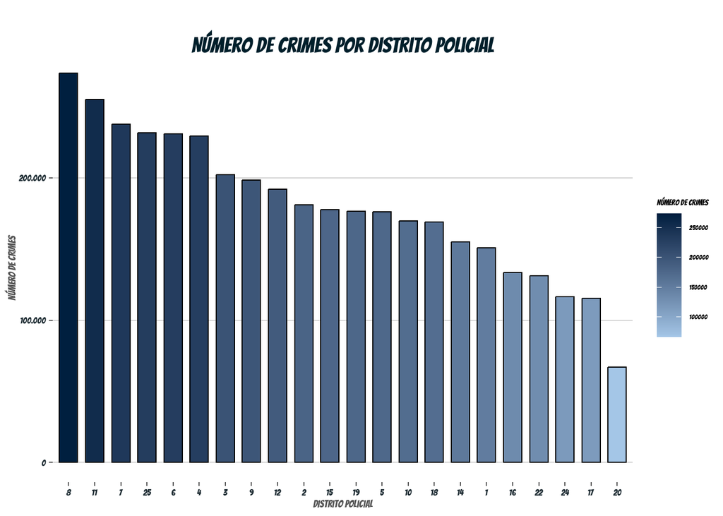

Número de crimes em cada distrito policial

```r
# gráfico de barras simples
ggplot(crimes_chicago2) +
  aes(x = reorder(distrito_char, -num_crimes), y = num_crimes, fill= num_crimes) +
    geom_bar(stat = "identity", color = "black", width = 0.7) +
    labs(
      x = "Distrito Policial",
      y = "Número de Crimes",
      title = "Número de crimes por distrito policial"
    ) +
    scale_y_continuous(
      labels = scales::label_comma(big.mark = ".", decimal.mark = ",") # Formatação do eixo Y
    ) +
    scale_fill_gradient(
      name = "Número de Crimes",
       low = "#A4C6E7",  # Cor inicial (valores baixos)
       high = "#001F3F"  # Cor final (valores altos)
    )+
    meu_tema()
```

#### Representação geoespacial

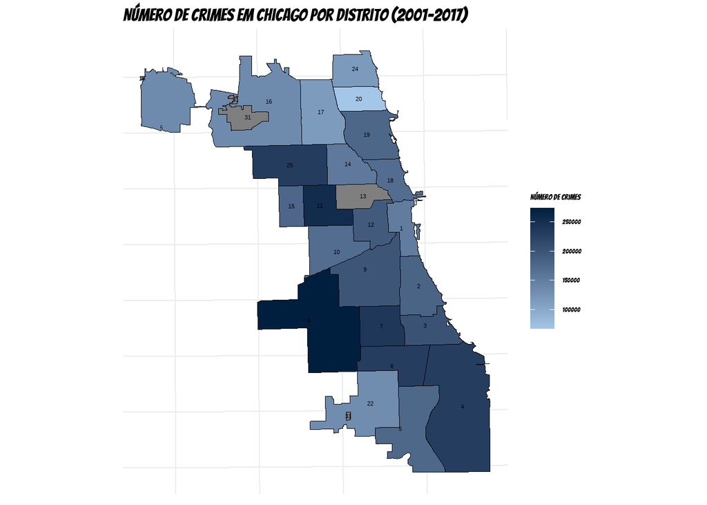

Distribuição do número de crimes por distrito no mapa

```r
## join para juntar os dados com a geometria
distritos2 <- distritos %>%
  left_join(crimes_chicago2, join_by(DIST_NUM== distrito_char))

## gráfico mapa
options(scipen = 999) ## p tirar o número em formato de notação científica
ggplot(data = distritos2) +
  labs(title = "Número de crimes em Chicago por distrito (2001-2017)")+
  geom_sf(aes(fill= num_crimes),color= "black") +
  geom_sf_text(aes(label= DIST_NUM), size=3, color="black")+
  scale_fill_gradient(name = "Número de crimes",
                          low = "#A4C6E7",
                          high = "#001F3F") +
  theme_minimal(base_family = "bangers")+
  scale_x_continuous()+
  theme(plot.title = element_text(size=25),
        axis.title.y = element_blank(),
        axis.title.x = element_blank(),
        axis.text.x = element_blank(),
        axis.text.y = element_blank())
```

#### Resultados

A análise descritiva teve como resultado que `crimes_chicago2$distrito_char[1]`, o distrito policial número 8, foi o que mais teve incidente de crimes com mais de 200 mil entre os anos de 2001 e 2017. Além disso, o tipo de crime com mais ocorrências nesse distrito foi o roubo com 53468 roubos.

Esse distrito, também conhecido como Chicago Lawn, é uma das áreas mais populosas e diversificadas da cidade. Tendo isso em vista,uma possível resposta para o elevado número de criminalidade na região é a densidade populacional, resultando em uma maior probabilidade de incidentes criminais simplesmente devido à presença de mais pessoas.

### 2.5 Análise descritiva dos Feriados

A cidade de Chicago conta com cerca de 10 feriados anuais, selecionados para esta análise com base no potencial impacto desses períodos festivos na ocorrência de crimes. Cada um desses feriados é marcado por celebrações que podem criar situações propensas ao aumento de crimes, colocando em risco a segurança dos cidadãos. Com isso, foram realizadas duas análises descritivas principais: a primeira, focada na distribuição de frequência, visa identificar os feriados com os maiores índices de crimes ao longo do ano; a segunda, tem como objetivo examinar os padrões mais frequentes de crimes, classificando-os em três categorias: crimes violentos, crimes de perturbação pública e crimes contra a propriedade, para investigar possíveis relações entre o tipo de crime e a data comemorativa.

#### Grafico de Barras Com Todos Os Acontecimentos de Crimes em Feriados durante os 2004 até 2017

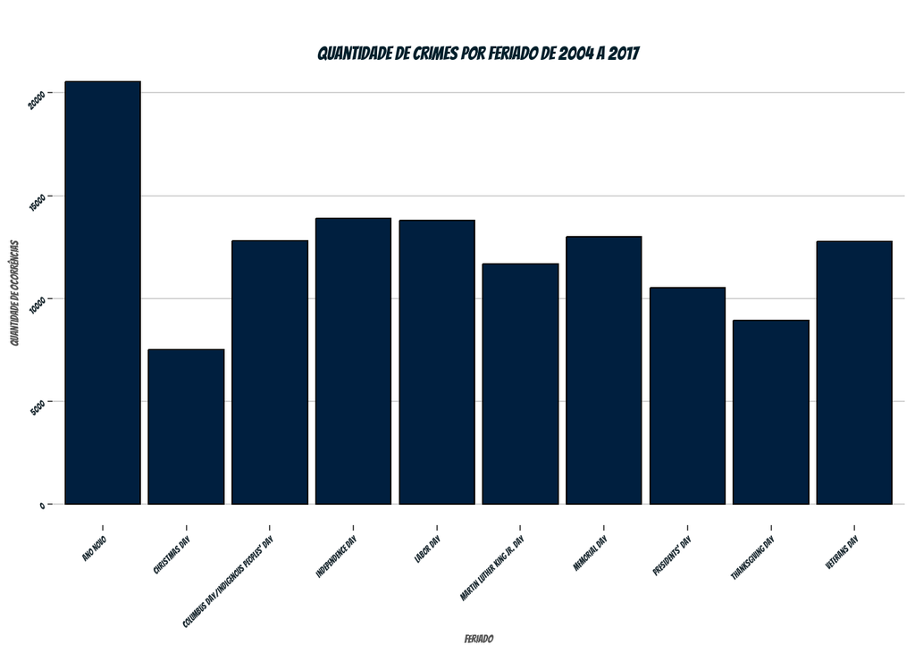

Quantidade de Crimes Por feriado De 2004 até 2017

```r
# gráfico de barras simples
ggplot(data_feriados, aes(x = Feriado)) +
  geom_bar(stat = "count", fill = "#001F3F", color = "black") +
  labs(title = "Quantidade de Crimes Por Feriado de 2004 a 2017",
       x = "Feriado", y = "Quantidade de Ocorrências") +
  theme_minimal(base_family = "bangers") +
  theme(
    plot.title = element_text(size = 20, face = "bold", hjust = 0.5, margin = margin(t = 20), color = "#001F2B"),
    axis.title = element_text(size = 12, face = "bold", color = "#555555"),
    axis.text = element_text(size = 10, color = "#1F2D34", angle = 45, hjust = 1),
    panel.grid.major.x = element_blank(),
    panel.grid.major.y = element_line(color = "#D3D3D3", size = 0.5),
    panel.grid.minor = element_blank(),
    axis.ticks = element_line(color = "#555555")
  )
```

#### Graficos de Pizza para a Proporção Dos Tipos De Crimes

```r
#| label: Função para o tema dos gráficos de pizza e tabelas para os dados

font_add_google("Bangers", "bangers")
showtext_auto() # Ativa o uso de fontes no gráfico

meu_tema2 <- function(){
  theme_minimal(base_family = "bangers") +
    theme(
      plot.title = element_text(size = 15, face = "bold", hjust = 0.5,  margin = margin(t = 20), color = "#001F2B"),
      axis.text = element_text(size = 10, color = "#1F2D34"),
      panel.grid.minor = element_blank(),
      axis.ticks = element_line(color = "#555555")
    )
}

proporcao_violento <- data_feriados %>%
  group_by(Violento) %>%
  summarise(count = n()) %>%
  mutate(proportion = count / sum(count))

proporcao_perturbacao <- data_feriados %>%
  group_by(Perturbacao_Publica) %>%
  summarise(count = n()) %>%
  mutate(proportion = count / sum(count))

proporcao_propriedade <- data_feriados %>%
  group_by(Propriedade) %>%
  summarise(count = n()) %>%
  mutate(proportion = count / sum(count))
```

#### Grafico de Proporção de Crimes Violentos

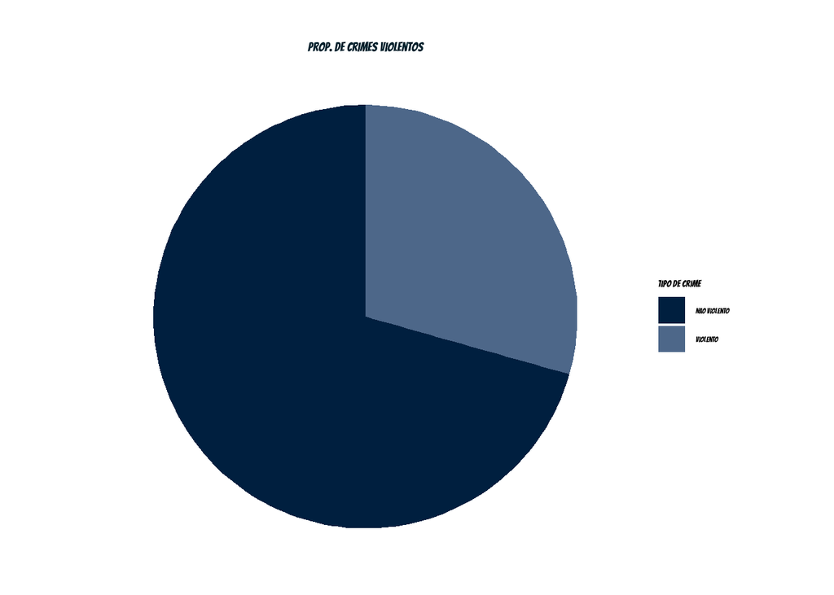

Proporção de Crimes Violentos em Feriados

```r
ggplot(proporcao_violento, aes(x = "", y = proportion, fill = Violento)) +
  geom_bar(stat = "identity", width = 1) +
  coord_polar(theta = "y") +
  theme_void() +
  labs(title = "Prop. de Crimes Violentos", fill = "Tipo de Crime") +
  scale_fill_manual(values = c(
    "Violento" = "#4D6789",
    "Nao Violento" = "#001F3F"
  )) +
  meu_tema2() +
  theme(
    axis.text = element_blank(),
    axis.ticks = element_blank(),
    panel.grid = element_blank(),
    axis.title = element_blank()
  )
```

#### Grafico de Proporção de Perturbação Pública

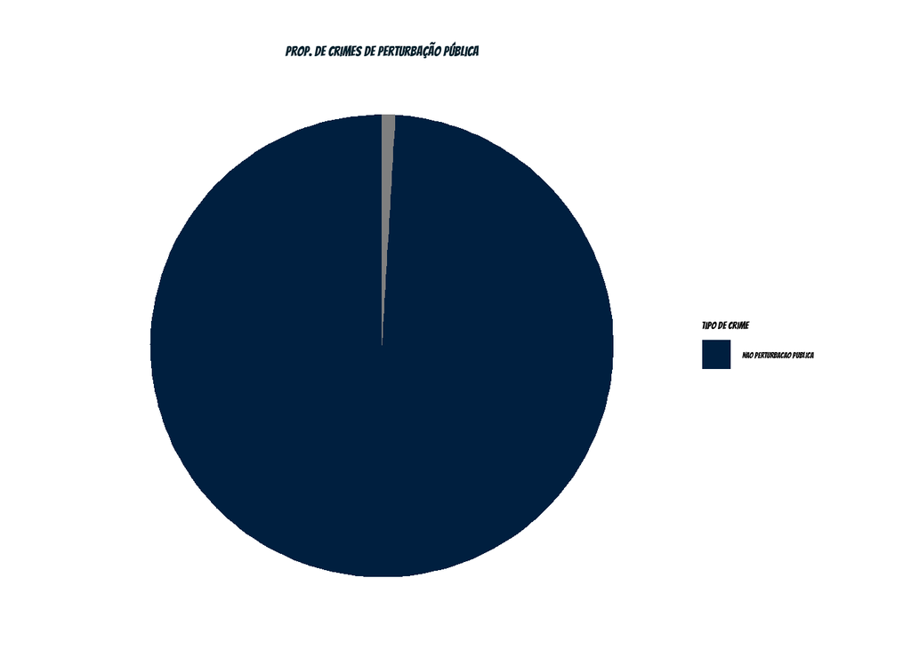

```r
#| fig-cap: Proporção de Crimes de Perturbação Pública em Feriados
#| label: fig-05

ggplot(proporcao_perturbacao,
       aes(x = "", y = proportion, fill = Perturbacao_Publica)) +
  geom_bar(stat = "identity", width = 1) +
  coord_polar(theta = "y") +
  theme_void() +
  labs(title = "Prop. de Crimes de Perturbação Pública", fill = "Tipo de Crime") +
  scale_fill_manual(values = c(
    "Perturbacao Publica" = "#4D6789",
    "Nao Perturbacao Publica" = "#001F3F"
  )) +
  meu_tema2() +
  theme(
    axis.text = element_blank(),
    axis.ticks = element_blank(),
    panel.grid = element_blank(),
    axis.title = element_blank()
  )
```

#### Grafico de Proporção de Crimes Contra Propriedade

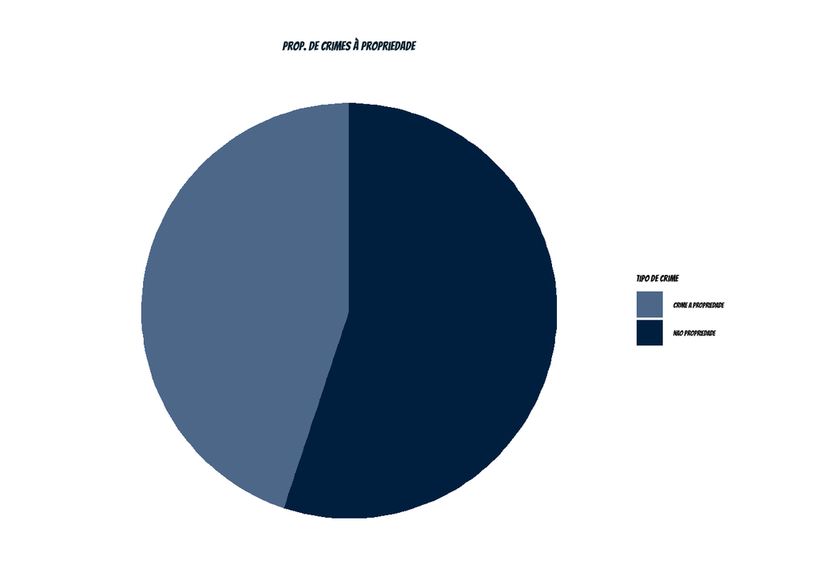

```r
#| fig-cap: Proporção de Crimes Contra Propriedade  em Feriados
#| label: fig-06

ggplot(proporcao_propriedade, aes(x = "", y = proportion, fill = Propriedade)) +
      geom_bar(stat = "identity", width = 1) +
      coord_polar(theta = "y") +
      theme_void() +
      labs(title = "Prop. de Crimes à Propriedade",
           fill = "Tipo de Crime") +
      scale_fill_manual(values = c("Crime a Propriedade" = "#4D6789",
                                   "Nao Propriedade" = "#001F3F")) +
      meu_tema2() +
      theme(axis.text = element_blank(),
            axis.ticks = element_blank(),
            panel.grid = element_blank(),
            axis.title = element_blank())
```

#### Resultados

O Ano Novo apresenta a maior taxa de crimes devido ao aumento das celebrações, consumo de álcool e aglomerações, o que pode gerar descontrole e comportamentos impulsivos. Esse cenário favorece crimes como agressões, furtos e distúrbios, além de tornar as ruas mais vulneráveis a delitos como roubos e furtos.

### 2.6 Teste qui-quadrado

O teste qui-quadrado é um teste de hipótese que avalia a associação existente entre variáveis qualitativas e váriaveis como tipo de crime `primary_type` e se ocorreu prisão ou não `arrest` estavam presentes no banco de dados analisado. Assim, com o intuito de verificar se há alguma relação significativa entre elas, foi feito o teste qui-quadrado de independência.

Primeiramente, foi verificado alguns tipos de crimes com a frequência muito baixa se comparada com as outras, então para o teste funcionar corretamente, foi agrupado os tipos de crimes que representavam menos de 1% do total de incidentes e foi chamado de `outro`. Após a alteração, foi criada uma tabela de contingência com os tipos de crimes e prisão para aplicar o teste. Sabendo que se p-valor é maior que 0,05 ele falha ao rejeitar a hipótese nula e se p-valor menor que 0,05 é rejeitada a hipótese nula, foi obtida para esta análise um p-valor= 2,2x 10^-16. Isto é, um valor extremamente baixo e indicando que há evidências fortes que o tipo de crime está associado à probabilidade de prisão.

#### Agrupamento de observações da variável tipo de crime

```r
crimes <- crimes_chicago %>%
  select(primary_type, arrest) %>%
  group_by(primary_type) %>%
  summarise(num_crimes =n()) %>%
  mutate(porcentagem = num_crimes / sum(num_crimes) * 100) %>%  #numero de crimes em porcentagem
  mutate(crimes_agrup = case_when(
    porcentagem < 1 ~ "OUTROS",
    TRUE ~ primary_type )) %>% ### agrupar incidentes de crimes mto pequenos
  group_by(crimes_agrup) %>%
  summarise(total_crimes =sum(num_crimes))
 # mutate(total_crimes_formatado = comma(total_crimes, big.mark = ".", decimal.mark = ","))

outros <- c(crimes$crimes_agrup[crimes$crimes_agrup != "OUTROS"])

crimes2 <- crimes_chicago %>%
  mutate(crimes_agrup = case_when(
    primary_type %in% c(outros) ~ primary_type,
    TRUE ~ "OUTROS"
  ))
```

#### Aplicando o teste

```r
tabela_crime_prisao <- table(crimes2$crimes_agrup, crimes2$arrest)

teste_qui <- chisq.test(tabela_crime_prisao)
print(teste_qui)
```

```
##
##  Pearson's Chi-squared test
##
## data:  tabela_crime_prisao
## X-squared = 1674527, df = 12, p-value < 0.00000000000000022
```

#### Gráfico de barras empilhados com as proporções de prisão por crime

Para ilustrar, foi feito um gráfico de barras empilhado mostrando a proporção de prisões por tipo de crime apresentada a seguir

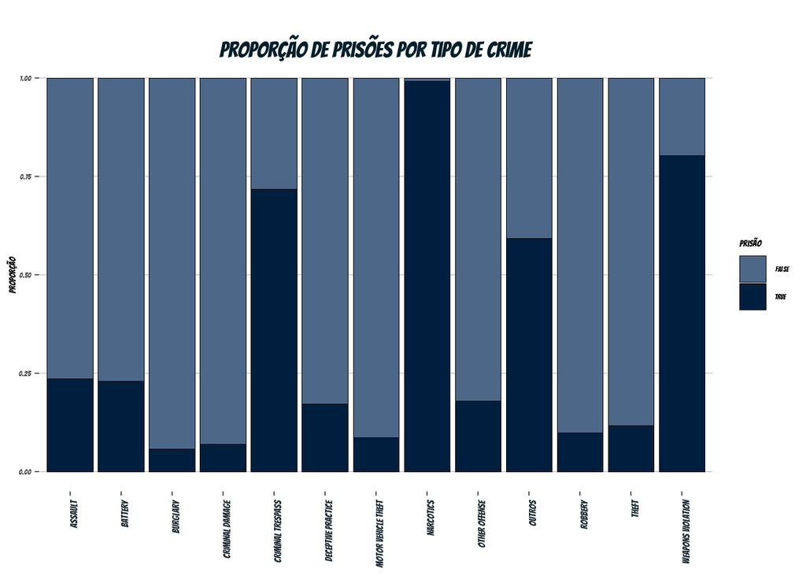

Proporção de prisões por tipo de crime

```r
font_add_google("Bangers", "bangers")
showtext_auto() # Ativa o uso de fontes no gráfico

grafico_empilhado <- crimes2 %>%
  count(crimes_agrup, arrest) %>%
  ggplot(aes(x = crimes_agrup, y = n, fill = arrest)) +
  geom_bar(stat = "identity", position = "fill", color = "black", size = 0.3) + # Adicionado contorno preto
  labs(
    x = NULL,
    y = "Proporção",
    fill = "Prisão",
    title = "Proporção de Prisões por Tipo de Crime"
  ) +
  scale_fill_manual(values = c("#4D6789", "#001F3F")) + # Ajuste as cores aqui
  theme_minimal(base_family = "bangers") +
  theme(
    axis.text.x = element_text(angle = 90, hjust = 1, size = 12, color = "#1F2D34"),
    plot.title = element_text(size = 28, face = "bold", hjust = 0.5, margin = margin(t = 20), color = "#001F2B"),
    panel.grid.major.x = element_blank(),
    panel.grid.major.y = element_line(color = "#D3D3D3", size = 0.5),
    panel.grid.minor = element_blank(),
    axis.ticks = element_line(color = "#555555")
  )

grafico_empilhado
```

#### Resultados

Assim, foi possível analisar a proporção de prisões por tipo de crime e é importante ressaltar que 12 crimes foram agrupados pela baixa incidência, então para estes, a proporção pode divergir um pouco dos verdadeiros valores. Ademais, certos crimes, como narcóticos (com 418.509 prisões e apenas 3.210 não prisões), mostram uma maior probabilidade de resultarem em prisão. Por outro lado, crimes como furto de veículo e arrombamento apresentam números muito altos de ocorrências sem prisão.

### 2.7 Análise descritiva Incidentes Criminais em Chicago ao Longo dos Meses

O estudo teve como foco analisar a frequência de incidentes criminais em Chicago ao longo dos meses do ano, explorando aspectos como a porcentagem de crimes resultando em prisões, a média mensal de ocorrências criminais e a distribuição de crimes por dia da semana.

Para visualização dos dados, um gráfico de linha foi elaborado para ilustrar a porcentagem de crimes com prisões em cada mês. Complementarmente, uma tabela resumiu as médias mensais de crimes. Adicionalmente, foi criado um mapa de calor que destacou a densidade de crimes em cada dia da semana, proporcionando uma visão clara das variações diárias na criminalidade.

#### Porcentagem Crimes com Prisão

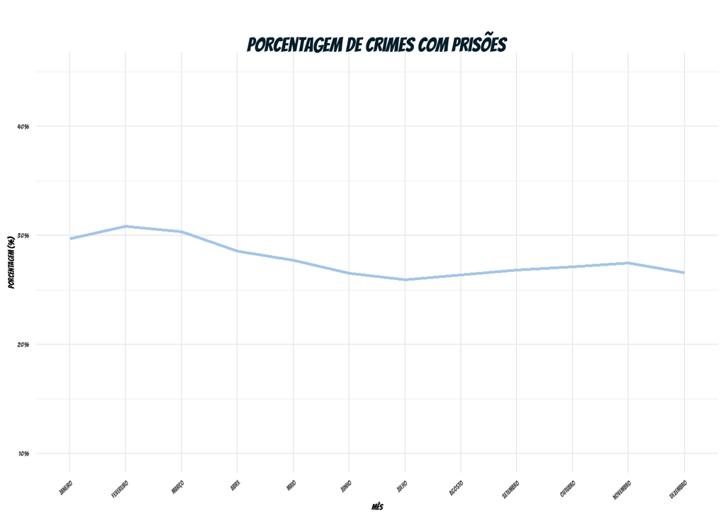

Porcentagem Crimes com Prisão

```r
tb2_filtrado<- tb1 %>%
    group_by(nome_mes) %>%
    summarise(
      total = n(),
      arrest_true = sum(arrest == TRUE, na.rm = TRUE),  # Evitar problemas com NA
      porcentagem = (arrest_true / total)
    )

font_add_google("Bangers", "bangers")
showtext_auto() # Ativa o uso de fontes no gráfico

ggplot(tb2_filtrado, aes(x = nome_mes, y = porcentagem, group = 1)) +
  geom_line(color = "#A4C6E7", linewidth = 1) +
  scale_y_continuous(limits = c(.1, 0.45), labels = scales::percent) +
  labs(
    title = "Porcentagem de Crimes com Prisões",
    x = "Mês",
    y = "Porcentagem (%)"
  ) +
  theme_minimal(base_family = "bangers") +
  theme(
    plot.title = element_text(size = 28, face = "bold", hjust = 0.5, margin = margin(t = 20), color = "#001F2B"),
      axis.text.x = element_text(angle = 45, hjust = 1))
```

#### Mapa de Calor Crimes por Mês e Dia da Semana

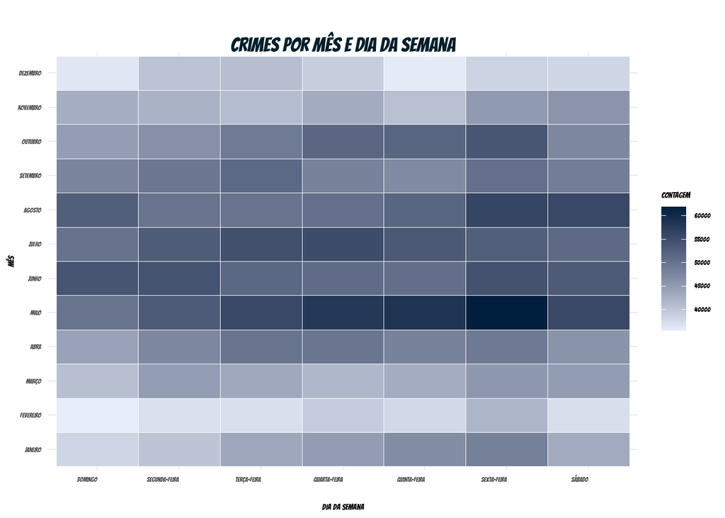

Mapa de Calor Crimes por Mês e Dia da Semana

```r
tb1_filtrado <- tb1 %>%
    group_by(nome_mes, dia_semana) %>%
    summarise(crimes = n(), .groups = "drop")

ggplot(tb1_filtrado, aes(x = dia_semana, y = nome_mes, fill = crimes)) +
    geom_tile(color = "white") +
    scale_fill_gradient(low = "#E7EDF9", high = "#001F3F") +
    labs(
      title = "Crimes por Mês e Dia da Semana",
      x = "Dia da Semana",
      y = "Mês",
      fill = "Contagem"
    ) +
    theme_minimal(base_family = "bangers") +
    theme(
      plot.title = element_text(size = 28, face = "bold", hjust = 0.5, margin = margin(t = 20), color = "#001F2B"),
      axis.title.x = element_text(margin = margin(t = 15)),
      axis.text.x = element_text(angle = 0,vjust = 1, hjust = 1)
    )
```

#### Tabela Média de Crimes por Mês

```r
crimes_mes <- tb1 %>%
    group_by(Mês = nome_mes) %>%
    summarise(
      Média = mean(n())
    )
tabelaa <- data.table(crimes_mes)
print(tabelaa)
```

```
##           Mês  Média
##  1:   janeiro 305387
##  2: fevereiro 265666
##  3:     março 304390
##  4:     abril 334744
##  5:      maio 393968
##  6:     junho 369289
##  7:     julho 370803
##  8:    agosto 367210
##  9:  setembro 343361
## 10:   outubro 345114
## 11:  novembro 301121
## 12:  dezembro 269133
```

### 2.8 Análise descritiva da média de crimes por localização

O objetivo da análise dessa seção é verificar a média de crimes por localização. Primeiramente, o total de observações distintas para a variável localização, `location_description`, é de 167, uma quantidade muita alta para avaliar no gráfico por exemplo. Então, foi agrupado observações com menos de 1000 ocorrências , consideradas baixas se comparadas com as outras, em uma só observação chamada `Outros`. Assim, foi possível dar continuidade ao estudo.

#### Tradução das observações

Aqui, realizamos as traduções das principais localidades para garantir que os nomes estejam uniformemente apresentados em português. Isso foi feito para criar um gráfico mais harmônico e coeso, evitando a mistura de idiomas que poderia comprometer a clareza da visualização.

```r
traducoes_locacao <- c(
  "STREET" = "Rua",
  "RESIDENCE" = "Residência",
  "APARTMENT" = "Apartamento",
  "SIDEWALK" = "Calçada",
  "OTHER" = "Outros",
  "PARKING LOT/GARAGE(NON.RESID.)" = "Estacionamento/Garagem (Não Residencial)",
  "ALLEY" = "Beco",
  "SCHOOL, PUBLIC, BUILDING" = "Escola, Público, Prédio",
  "RESIDENCE-GARAGE" = "Residência-Garagem",
  "SMALL RETAIL STORE" = "Pequena Loja de Varejo",
  "RESIDENCE PORCH/HALLWAY" = "Varanda/Corredor da Residência",
   "VEHICLE NON-COMMERCIAL" = "Veículo Não Comercial",
   "RESTAURANT" = "Restaurante",
  "DEPARTMENT STORE" ="Loja de Departamentos",
    "GROCERY FOOD STORE" = "Mercado/Loja de Alimentos",
    "RESIDENTIAL YARD (FRONT/BACK)" = "Pátio Residencial (Frente/Fundos)",
   "GAS STATION" = "Posto de Gasolina"
)

crimes_chicago$locations_description <- traducoes_locacao[crimes_chicago$locations_description]
```

#### Cálculo da média

```r
localizacao <- crimes_chicago %>%
  mutate(loc_agrup = case_when(
    locations_description %in% names(which(table(crimes_chicago$locations_description) >= 1000)) ~ locations_description,
    TRUE ~ "Outros"
  )) %>%
  group_by(loc_agrup) %>%
  summarise(media = mean(n())) %>%
  arrange(desc(media))
```

#### Tabela dos resultados

```r
tabela <- data.table(localizacao)
setnames(tabela, old = c("loc_agrup", "media"), new = c("Localização", "Média"))

print(tabela)
```

```
##                                  Localização   Média
##  1:                                      Rua 1027568
##  2:                               Residência  653878
##  3:                                   Outros  623887
##  4:                              Apartamento  430017
##  5:                                  Calçada  417097
##  6: Estacionamento/Garagem (Não Residencial)  112651
##  7:                                     Beco   90402
##  8:                  Escola, Público, Prédio   84531
##  9:                       Residência-Garagem   78270
## 10:           Varanda/Corredor da Residência   70137
## 11:                   Pequena Loja de Varejo   69891
## 12:                    Veículo Não Comercial   63383
## 13:                              Restaurante   60903
## 14:                    Loja de Departamentos   49407
## 15:                Mercado/Loja de Alimentos   49008
## 16:        Pátio Residencial (Frente/Fundos)   47728
## 17:                        Posto de Gasolina   41428
```

#### Gráfico lollipop com a média de crimes por local

```r
localizacao2 <- localizacao %>%
  top_n(20) %>%
  arrange(desc(media))
```

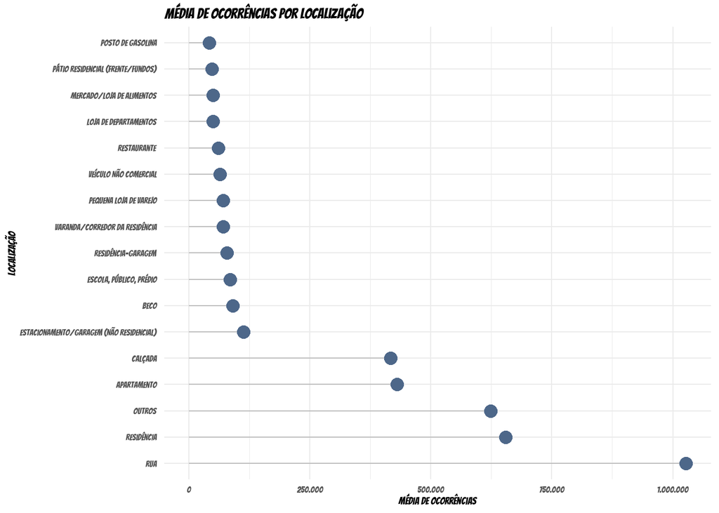

Gráfico da média de crimes por localidade

```r
font_add_google("Bangers", "bangers")
showtext_auto()

ggplot(localizacao2, aes(x = reorder(loc_agrup, -media), y = media)) +
  geom_segment(aes(xend = loc_agrup, yend = 0), color = "grey") +
  geom_point(color = "#4D6789", size = 4) +
  coord_flip() +
  labs(
    title = "Média de Ocorrências por Localização",
    x = "Localização",
    y = "Média de Ocorrências"
  ) +
  scale_y_continuous(labels = label_number(big.mark = ".", decimal.mark = ",")) +  # Adiciona separadores
  theme_minimal(base_family = "bangers") +
  theme(
    plot.title = element_text(size = 20, face = "bold", color = "black"),
    axis.title = element_text(size = 14, color = "black"),
    axis.text = element_text(size = 12, color = "#555555")
  )
```

## 3 Discussões

As análises apresentadas revelaram diversos aspectos importantes sobre a dinâmica da criminalidade em Chicago ao longo dos anos e destacou como fatores temporais, espaciais e contextuais influenciam os padrões criminais.

## 4 Referências

Scout, Neighborhood. 2024. «Chicago Crime Rates and Statistics». https://www.neighborhoodscout.com/il/chicago/crime#description.

Wikipedia. 2024. «Chicago». https://en.wikipedia.org/wiki/Chicago.